# Bruhn_C13_4

このような状況が生じる場合は、薄い材料の連続する層を介して応力を逃がすか、最初の取り付け点に向けて徐々にテーパーを設けることが解決策となる。

これが不可能な場合は、スパー内の応力の方向に対して垂直に重い部品を分割し、「呼吸スペース」を設けることができるかもしれない。穴自体から生じる応力変動を低減するためには、取り付け点にテーパーボルトを使用することが役立つ。しかし、横目方向における鍛造品の応力腐食感受性のため、締まりばめは鍛造品ではなくスパーウェブ内に行うべきである。

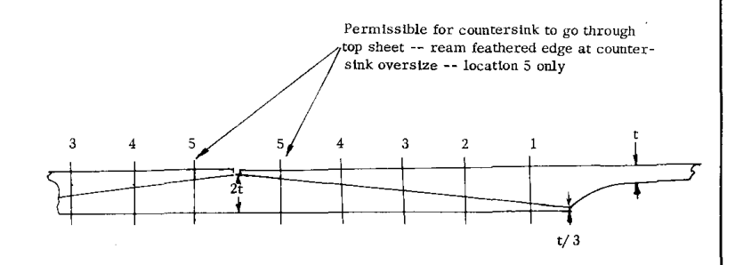

Fig. C13.61

### C13.8.3 1面せん断フラッシュジョイント

機械的に締結されたフラッシュタイプの継手を設計する際の一般的な誤りは、厚すぎる継手板（スプライスプレート）を使用することである。これは、締結具のせん断、板の引張強度、支圧、および引き裂きがすべて等しくなるようにすることが良い手法と考えられている静的強度設計の結果である。接合される材料と等しいかそれよりも重い継手板は、荷重源に最も近い最初の締結具に過大な負荷をかけ（Fig. C13.41参照）、最初の締結具に疲労亀裂を発生させる原因となる。

疲労を考慮した設計では、荷重に最も近い最初の締結具は、接合される材料を疲労破壊させるような荷重を負担できないようにすべきである。より小径の締結具を使用することは、単に締結具自体にトラブルを招くだけである。より良い方法は、Fig. C13.61に示すように、接合される材料の端部を厚くし（彫刻されたスキン）、スカーフを使用して荷重分布を改善することである。

重要な領域は、締結具No. 1におけるスキンと、締結具No. 5における継手板である。したがって、これらの場所の応力を緩和するためにできることはすべて有益である。締結具No. 5の場合、皿穴が外板を完全に貫通することを許容している。通常、これは決して許されるべきではないが、この場所で継手板が破壊しないことを保証する一つの方法である。これは、ここが継手板の最大曲げ位置であり、疲労亀裂の検出が困難な視野から隠れた場所であるため、特に重要である。

同様の状況が締結具No. 1にも存在し、ここでは締結具のせん断強度が継手板の支圧強度を確実に上回るように特別な予防措置を講じる必要がある。したがって、過負荷によって保護しようとしている材料内の締結具が緩むことはない。ダブラーに永久支圧変形が生じたとしても、それは疲労の原因となる荷重を単に緩和するだけであるため、致命的ではない。位置2、3、および4の締結具は、静的要件のほぼ完全に満たす荷重を伝達できる必要がある。

### C13.8.4 締結具のサイズ

一般的な誤りは、小さすぎる締結具を使用することである。穴による応力集中は、穴のサイズに関係なくほぼ同じであることを覚えておいてほしい。より大きな締結具は、より広い支圧面積を提供し、それほど曲がらず、取り付け公差も大きくなる（Fig. C13.62参照）。さらに、より大きな締結具を使用すると、材料のスタックアップ比（締結具直径/材料厚さの比）が良くなる。疲労試験では、スタックアップ比が3直径の試験片は、1または2直径の比を持つ試験片に比べて、寿命が1/10から1/5しかなかったことが示されている。

小さな締結具への傾向がある理由の一つは、より高強度の締結具が利用可能になったことである。これにより、ある程度の軽量化が達成されたが、アンダーサイズの締結具を使用するよりも、軽量化のためのより良い方法がおそらく存在する。

[figure not shown]

Fig. C13.62

### C13.8.5 音響疲労

音響疲労はそれ自体が独立した研究分野であり、したがって本セクションの範囲を超えているが、ジェットノイズやプロペラブラストによって誘発される音波振動への曝露が、空気力学的荷重によって引き起こされるものとは多少異なる疲労問題をもたらす場合、特定の予防措置を講じることができる。

設計における最も一般的な誤りは、非対称のリブ構造を使用することであり、これによりロール運動がFig. C13.63(a)に示すようにリブのウェブ上またはリベットのラインを通過して亀裂を発生させる。これに対する修正は、Fig. C13.63(b)に示すように、アングルを追加して断面をより対称的にすることによって行うことができる。しかし、さらに優れた解決策は、丸みを帯びたフランジ端部を持つ押し出しT型またはH型断面を使用することである。丸みを帯びたフランジは、Fig. C13.63(a)のように端部上のスキンが割れるのを防ぐのに役立つ。

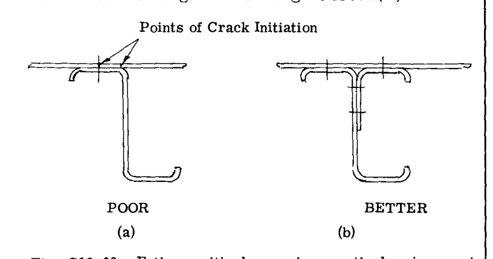

Fig. C13.63

スキンとストリンガーまたはリブの間に粘弾性材料の層を設けることが役立つ。既知の危険領域において、スキンの内側に燃料シーリング剤を塗布することが役立った事例もある。

一見すると、音響疲労に対する最善の設計は、システムの共振周波数を上回るような質量と剛性を持つ部品を設計することであるように思われる。しかし、エンジンの運転や離陸時に周波数の全スペックを経験するため、これは事実上不可能である。幸いなことに、各周波数での持続時間は非常に短い。しかし、適切な制振材料を使用することで応力を低減することができる。

## C13.9 チェックリスト

1. 適切な表面仕上げが指定されているか？一般的には125 r.m.s.以上、応力集中部では60以上の滑らかさ。
2. 機械加工の不一致は回避されているか？断面変化部で機械加工面を滑らかに繋ぐために、必要に応じて手仕上げを指定すること。
3. 危険領域におけるショットピーニングは指定されているか？設計マニュアルを参照するか、使用すべき適切なプロセスについて援助を求めること。
4. 横目方向の高度な応力は回避されているか？
5. 全体にわたって寛大な（大きな）半径（アール）が使用されているか？
6. スポットフェーシング（座ぐり）はどうか？スポットフェースツールは、適切なコーナー半径を提供するように修正されているか？
7. 断面の変化はできるだけ緩やかか？効果的な場合は流線型のフィレットを使用すること。
8. 開口穴はどうか？疲労向上のためにテーパーボルトを使用し、他の目的のためにその領域に開口穴を残すことは無意味である。穴を塞ぐか、干渉ばめブッシングを使用するかの適切な対策が講じられていることを確認すること。これが不可能な場合は、穴周辺の材料を厚くする必要がある。
9. 継手、部品、フィッティングなどは偏心しているか？もしそうなら、それ以外の方法で設計することは可能か？
10. すべての鋭いエッジは面取りされているか？穴はバリ取りされているか？
11. 硬質めっきが使用されている場所では、疲労強度の低下を補うためにショットピーニングが指定されているか？
12. 陽極酸化被膜（アルマイト）はどうか？硬質被膜（硫酸）は疲労亀裂に対して脆弱である。クロム酸または軟質アルマイトを使用すること。
13. 応力腐食？短幅方向の横目方向に持続的な応力が生じるのを防ぐために、適切な予防措置が講じられているか？
14. 各継手について、荷重に最も近い最初の締結具が、残りの締結具よりも少ない荷重を負担していることを確認するために検査が行われたか？最初の締結具における継手材料は、締結具がせん断される前に支圧破壊を確実に起こすほど十分に薄くあるべきである（Fig. C13.8.3を参照）。
15. 疲労危険領域の検査のためのアクセスは確保されているか？

## C13.10 結びの言葉

前述の通り、疲労の最も基本的な側面しかカバーできなかったが、読者が参考文献の資料を利用して、疲労問題のある領域を予見し修正する能力をさらに高めることを望む。

本書の執筆時点では、疲労は構造物が静的強度ではなく疲労耐性を考慮して設計される段階にはまだ達していないが、静的設計において最後の1オンスまで軽量化を追求し、疲労を考慮しない設計を行うことは無意味であると思われる。これが、私たちが今日まで非常に多くの疲労問題を経験してきた理由である。過大な応力を考慮して設計しているというよりも、応力が適切な分布を持つように配慮していないのである。

設計者が直面する多くの可能性を考慮しようと努めてきたが、これらは通常、航空機構造に見られるものに限定されていた。カバーされなかったいくつかの点には、低サイクル疲労、歪みサイクル、摩耗、腐食、熱サイクル、フラクトグラフィ、接着接合、サンドイッチ構造など、多くのものがある。これらの一部は参考文献に含まれているが、参考文献は現在利用可能な文献のほんの一部にすぎないことを覚えておく必要がある。

最後に、現在執筆されているように、疲労耐性のための設計が必ずしもコスト（重量）の増加を伴うわけではないという点を、いくら強調しても強調しすぎることはない。この一例として、300機の軍用機が、望ましい疲労寿命を達成するために改造されたケースがある。1機あたり3200人時間、総額11,000,000ドルの費用（材料費を含む、文献33より）がかかった。最終的な航空機は、元の航空機よりも重くはならなかった。元の重量は最適設計に基づいていなかったため、改造された航空機でさえ将来設定される疲労基準を満たさない可能性があると主張されるかもしれない。それはともかく、静的考慮のために重量を削減するより効率的な設計が期待できる一方で、疲労耐性を高める設計の革新も期待できる。

## REFERENCES

1. Shanley, F. R., “Fatigue Analysis of Aircraft Structures,” RAND Report No. 1127, July 1953.
2. Frocht, Max M. & Hill, “Stress-Concentration Factors Around a Central Circular Hole in a Plate Loaded Through a Pin in the Hole,” Journal of Applied Mechanics, March, 1940.
3. Frocht, Max M., *Photoelasticity*, Vol. I, John Wiley & Sons, Inc., 1941.
4. Sjostrom, S., “Stress Concentration Factor at the Edge of an Eccentrically Located Circular Hole in a Sheet in Tension.”, Swedish Aeronautical Institute Report No. 36.
5. Timoshenko, S., *Theory of Elasticity*, McGraw-Hill Book Co., Inc., New York 1934.
6. Lipson, Noll, & Clock, *Stress and Strength of Manufactured Parts*, McGraw-Hill, New York 1950.
7. Smith, Clarence R., “A Method for Estimating the Fatigue Life of 7075-T6 Aluminum Alloy Aircraft Structures,” U.S. Naval Air Engineering Center Report No. NAEC-ASL 1096, December 1965.
8. *Metallic Materials and Elements for Aerospace Vehicle Structures*, MIL Handbook 5, Department of Defense, Washington 25 DC.
9. Neuber, H. & Bertele, L., “Stress Concentration with Fatigue Loading”, Air Force Materials Laboratory Report AFML-TR-70-45, February 1970.
10. Goodman, J., *Mechanics Applied to Engineering*, Longmans, Green & Co., London 1899.
11. Grover, H.J., Gordon, S.A., and Jackson, L.R., *Fatigue of Metals and Structures*, U.S. Govt. Printing Office, 1954.
12. Findley, W.N., “Fatigue of 76S-T61 Aluminum Alloy under Bending & Torsion”, ASTM Proceedings, 1952.
13. Gough, H.J. and Pollard, H. V., “The Strength of Metals under Combined Alternating Stresses”, Institution of Mechanical Engineers, Vol. 131 1935; “The effect of Specimen Form on the Resistance of Metals to Combined Alternating Stresses”, Vol. 132, 1936.
14. Fritte, P.H., “Fatigue Tests on Crankshaft Steels,” *Journal of the Iron and Steel Institute*, Vol. 159, 1948.
15. McAdam, D.J. Jr., “Endurance Properties of Steel: Their Relation to Other Physical Properties and to Chemical Composition”, ASTM Proc. Vol. 23, 1923.
16. Christensen, R.H., “The Fatigue of Materials and Structures”, Collection of Notes for In-Plant Course on Fatigue at Douglas Aircraft Co., Inc., Santa Monica, Calif. 1954.
17. Moroney, N.J., *Facts from Figures*, Penguin Books, Baltimore 1954.
18. Rosenfeld, M.S., “Navy Research on Structural Fatigue”, ASTM Special Technical Publication No. 338, 1962.
19. Payne, A.O., Ford, D.G., et al., “Fatigue Characteristics of Riveted 24S-T Aluminum Alloy Wing, Part V: Discussion of Results and Conclusions”, Aeronautical Research Laboratories Report SM 268, Melbourne 1959.
20. Cummings, H.N., Stulen, F.B., & Schulte, W.C. “Investigation of Materials Fatigue Problems Applicable to Propellor Design”, WADC-TR 54-531, May 1954.
21. Smith, Clarence R., “Preventing Fatigue Failures”, *Assembly Engineering*, April 1968.
22. Griffith, George E., “Experimental Investigation of the Effects of Plastic Flow in Tension Panel with a Circular Hole,” NACA T.N. 1705, Langley Field, Va.
23. Almen, J. O., “Shot Blasting to Increase Fatigue Resistance”, *SAE Journal (Transactions)*, Vol. 51, No. 7.
24. Fuchs, Henry O., “Techniques of Surface Stressing to Avoid Fatigue”, Published in *Metal Fatigue*, Edited by George Sines & J.L. Waisman, McGraw Hill Book Co., Inc., N.Y. 1959.
25. Whaley, Richard E., “Improvement in 7075-T6 Aluminum Alloy Fatigue Life by Coining”, ASTM Proceedings, Vol. 63, 1963.
26. Inglis, I. N., “Nitriding Offsets Notch Weakness”, Abstract, *Iron Age*, Vol. 147, No. 1.
27. Almen, J. O., “Fatigue Loss and Gain by Electro-plating”, *Product Engineering*, Vol. 22, No. 6, June 1951.
28. Smith, Clarence R., “Evaluation of Fatigue Life of Chrome-Plated Specimens”, AFFDL-TR-65-166, Wright-Patterson AFB, Ohio, December 1965.
29. Holshouser, W. L. & Utech, H. P., “Effect of Oleophobic Films on Fatigue Crack Propagation”, paper presented at the 64th annual meeting of ASTM, June 1961.
30. Smith, C.R., “Design Applications for Improving Fatigue Resistance of Airplane Structures,” *Proc. ASTM*, Vol. 60, 1960.
31. Smith, Clarence R., “The Effect of Tapered Bolts on Structural Integrity,” *Assembly Engineering*, July 1967.
32. Smith, Clarence R., “Frontiers in Fastener Design”, *Assembly Engineering*, Jan. 1969.
33. Smith, Clarence R., “Tips on Fatigue,” NAVWEPS 00-25-559, U.S. Govt. Printing Office, Washington DC, 1963, Price 70¢.
34. Smith, C. R., “Thin Doublers for Fatigue-Resistant Aluminum Alloy Structures”, *Aero/Space Engineering*, Feb. 1959.
35. Smith, C.R., and Zandman, F., “Photostress Plastic for Measuring Stress Distribution Around Rivets”, *SESA Proceedings*, Vol. XVII, No. 1, 1958.
36. Smith, Clarence R., “Effective Stress Concentrations for Fillets in Landed Structures”, *Experimental Mechanics*, April 1971.
37. Peterson, R. E., *Stress Concentration Design Factors*, John Wiley & Sons, Inc., New York 1953.
38. Christensen, R.H., & Bellinfonte, R.J., “Some Considerations in the Fatigue Design of Launch and Spacecraft Structures”, NASA - CR-242, June 1965.
39. Rhode, Richard V., and Donely, Phillip, “Frequency of Occurrence of Atmospheric Gusts and Related Loads on Airplane Structures”, NACA ARR No. L412J.
40. “Airplane Strength and Rigidity, Reliability Requirements, Repeated Loads, and Fatigue”, MIL-A-8866 (ASG), 1960.
41. Palmgren, A., “Die Lebensdauer von Kugellagern”, *Z. Ver. Deut. Ing.*, Vol. 68, 1924.
42. Miner, M.A., “Cumulative Damage in Fatigue”, *J. Appl. Mech.*, Vol. 12, 1945.
43. Smith, C.R., and Lindeneau, G.D., “Riveted Joints–Fatigue Strength”, ASTM Special Publication STP 203, 1957.
44. Fitch, G.E., Jr., Jackman, R.E., and Horsfall, W.P., “The F-100 Structural Integrity Program (ASIP)”, *Proceedings of the Air Force Conference on Fatigue and Fracture of Aircraft Structures and Materials*, Air Force Flight Dynamics Laboratory Report No. AFFDL TR 70-144, 1970.
45. Grover, Horace J., *Fatigue of Aircraft Structures*, NAVAIR 01-1A-13, U.S. Govt. Printing Office, Washington DC, 20402, 1966 (Price $1.25)
46. Wilhelm, D. P., “Fracture Mechanics Guidelines for Aircraft Structural Applications”, AFFDL-TR 69-111, 1969.

## BIBLIOGRAPHY

A.S.T.M. Special Publications, Published by the American Society for Testing and Materials, 1916 Race St., Philadelphia, Pa. 19103:  
- STP 9, *References on Fatigue*  
- STP 91, *Manual on Fatigue Testing*  
- STP 203, *Fatigue of Aircraft Structures*, 1957  
- STP 237, *Symposium on Basic Mechanism of Fatigue*, 1959  
- STP 274, *Symposium on Fatigue of Aircraft Structures*, 1960  
- STP 284, *Symposium on Acoustical Fatigue*, 1961  
- STP 338, *Symposium on Fatigue Tests of Aircraft Structures: Low-cycle Full-Scale, and Helicopters*  
- STP 378, *Internal Friction, Damping, and Cyclic Plasticity*, 1965  
- STP 467, *Achievement of High Fatigue Resistance in Metals and Alloys*.

American Society for Mechanical Engineers. Conference (International) on Fatigue of Metals – Proceedings, 29 West 39th St., New York 1956.

American Society for Metals. *Metals Handbook*, Vol. I, 8th Edition, Metals Park, Novelty, Ohio, 1961.

Baldi, Robert W., “The Smith Hypothesis on Metal Fatigue”, Master’s Thesis, San Diego State College, Dept. of Mechanical Engineering, January 1971.

Baum, C.P., “Reliability of Airframe Structures – General Aspects of the Problem and Outline of Methods for Attaining,” SAE-ASME-AIAA, Reliability and Maintainability Conference, 1964.

Bennett, J.A., “The Distinction between Initiation and Propagation of a Fatigue Crack,” International Conference on Fatigue of Metals (London and New York), 1956.

Carter, T.L., Zaretsky, E.V., and Anderson, W.J., “Effect of Hardness and Other Mechanical Properties on Rolling-Contact Fatigue of Four High-Temperature Bearing Steels,” NASA-TN-D270, 1960.

Cazaud, Roger, *Fatigue of Metals*, Champion & Hall, London 1953.

Corten, H.T., and Dolan, T.J., “Cumulative Fatigue Damage.” IME-ASME International Conference on Fatigue, 1956.

Critchlow, W., “The Ultimate Strength of Damaged Structure”, *Symposium on Full-Scale Fatigue Testing of Aircraft Structures*, Pergamon Press, N. Y., 1961.

Dixon, J. R., "The Effect of Local Plastic Deformation on the Stress Distribution around a Crack, National Engineering Laboratory Report No. 71, 1962.

Douglas Aircraft Co., “Investigation of Thermal Effects on Fatigue,” WADD TN-50-410, Part I, 1960, Part II, 1961.

Durelli, A.J., “Elastoplastic Stress and Strain Distribution in a Finite Plate with a Circular Hole Subjected to Unidimensional Load,” *Journal of Applied Mech. (ASME)*, Vol. 30, March 1963.

Forrest, P.G., *Fatigue of Metals*, Pergamon Press, N.Y. 1962.

Forsythe, P.J.E., “Fatigue Damage and Crack Growth in Aluminum Alloys,” *Acta Metallurgica*, Vol. 11, 1963.

Freudenthal, A.M., (Editor). *Fatigue in Aircraft Structure* (Proceedings of the International Conference Held at Columbia University), January 30, 31, and February 1, 1956.

Freudenthal, A.M., and Heller, R.A., “On Stress Interaction in Fatigue and a Cumulative Damage Rule,” *Journal of Aero-Space Science*, Vol. 26, No. 7, 1959.

Gurney, T.R., “Influence of Artificially Induced Residual Stresses on Fatigue Strength of Load-Carrying Fillet Welded Joints in Mild Steel,” *Welding Research Council Bulletin*, Vol. 8, 1962.

Halford, G .R., and Morrow, J., “Low Cycle Fatigue in Torsion,” University of Illinois TAM Report No. 203, 1961.

Harris, W.J., *Metallic Fatigue with Particular Reference to Significance of Certain Standard Aircraft Fabrication and Finishing Process*, Pergamon Press, N.Y. 1961.

Heywood, R.B., *Designing by Photoelasticity*, Academic Press Inc., Publishers, N.Y. 1952.

Heywood, R. B., *Designing Against Fatigue of Metals*, Reinhold Publishing Co., N.Y. 1962.

Hardrath, H. F., and Ohman, L., “A Study of Elastic and Plastic Stress Concentration Factors Due to Notches and Fillets in Flat Plates,” NACA Report 1117, 1953.

Illg. W., “Fatigue Tests on Notched and Unnotched Sheet Specimens of 2024-T3 and 7075-T6 Aluminum Alloys and of SAE 4130 Steel with Special Consideration of Life Range from 2 to 10,000 Cycles,” NACA TN 3866, Dec. 1956.

Kuhn, P., and Figge, I., “Unified Notch Strength Analysis for Wrought Aluminum Alloys,” NASA - TN-D-1259, 1962.

Manson, S.S., *Thermal Stress and Low-Cycle Fatigue*, McGraw-Hill, N.Y. 1966.

Marin, J., *Mechanical Behavior of Engineering Materials*, Prentice-Hall, N.Y. 1962.

Melcon, M.A. and McCullogh, A.J., “Simulation of Random Aircraft Service Loading in Fatigue Tests,” Third AGARD - ICAF Symposium on Aeronautical Fatigue, 1963.

Paris, P. C. “The Fracture Mechanics Approach to Fatigue,” *Proc. 10th Sagamore Army Materials Research Conference*, Syracuse University Press, Syracuse, N.Y. 1964.

Plantema, F.J. & Schijve, (Editors), *Full-Scale Fatigue Testing of Aircraft Structures*, Pergamon Press, N.Y. 1961.

Plunkett, R. and Lee, C.T., “Optimum Configurations for Damping by Constrained Viscoelastic Layers,” AFML-TR-68-376, Air Force Materials Lab., Wright Patterson AFB, Ohio 1969.

Schive, J., “Endurance Under Program Fatigue Testing” Amsterdam Symposium on Full-Scale Fatigue Testing of Aircraft Structures, Pergamon Press, N. Y., 1961.

Stowell, E. Z., “Stress and Strain Concentration at a Circular Hole in an Infinite Plate,” NACA TN2073, April 1950.

Teed, P.L. “Fretting,” *Metallurgical Review*, Vol. 5, 1960.

Wang, D. Y., “The Effect of Stress Distribution on the Fatigue Behavior of Adhesive Bonded Joints,” ASD-TDR-63-93, 1963.

Weibull, W., *Fatigue Testing and Analysis of Results*, Pergamon Press, N.Y. 1961.

# APPENDIX A–FATIGUE DATA

これらのデータを適用する際には、提示されている値が平均値であり、保証された最小値ではないことに注意して、ある程度の警戒を払う必要がある。また、ノッチデータ（切欠きデータ）の多くは、ノッチの厳しさを結晶粒度に関連付ける「ニューバー効果（Neuber effect）」が生じるほど十分に小さなノッチを持つ試験片で得られたものと思われる。したがって、より大きな構造物において幾何学的形状が同じであっても、応力集中はより厳しくなる可能性がある。$ 10^7 $サイクル付近で$ K_t $がほぼ$ K_f$に等しくなるため（C13.2を参照）、これらのデータで使用されているノッチの厳しさを判断し、必要に応じて適切な補正を行うことができる。

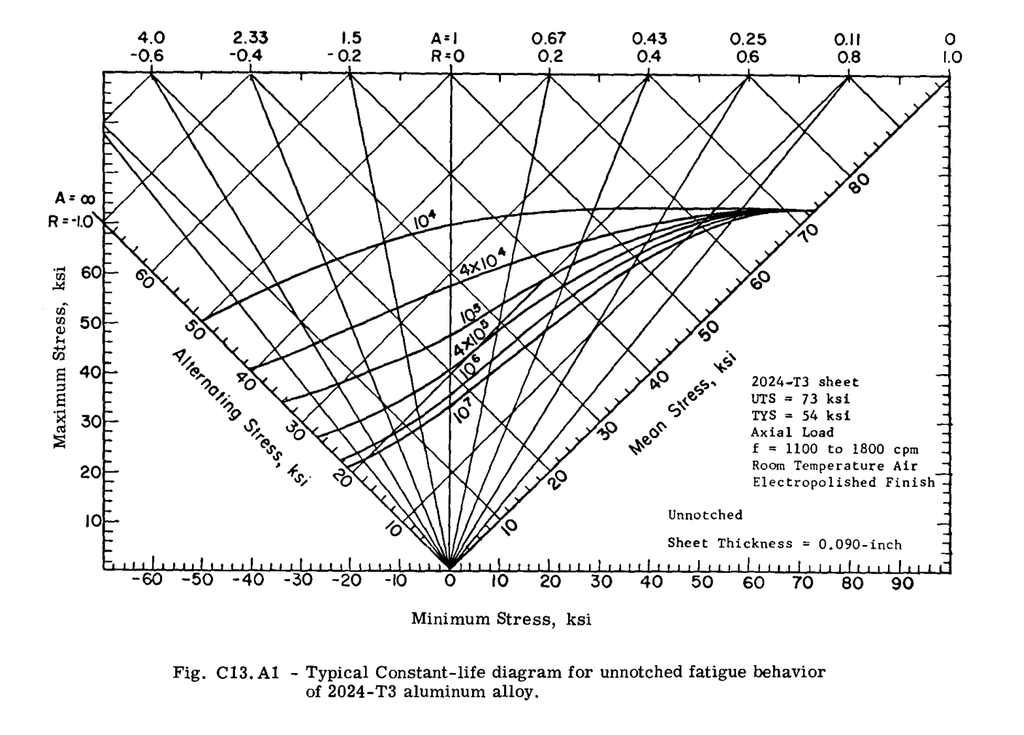

Fig. C13.A1

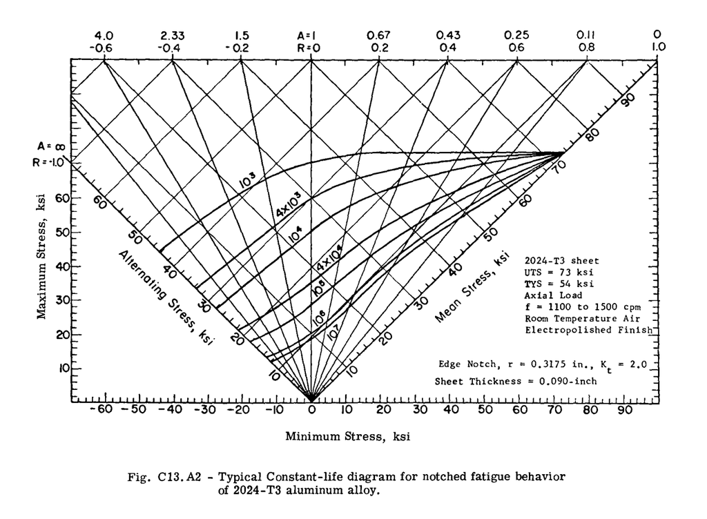

Fig. C13.A2

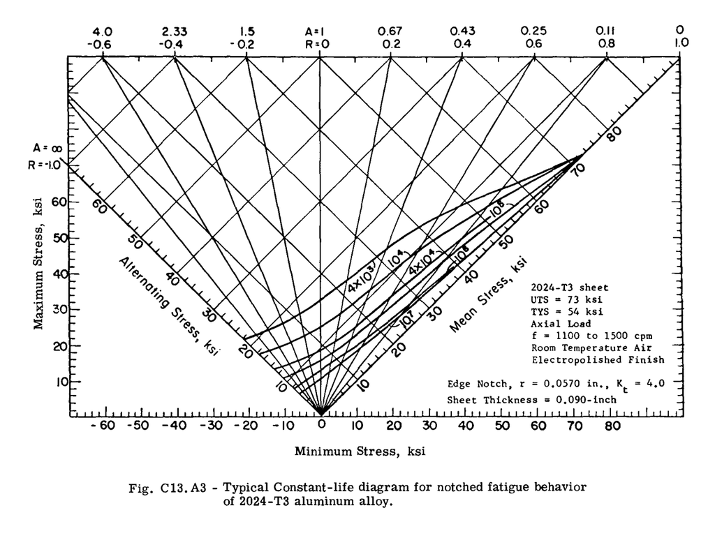

Fig. C13.A3

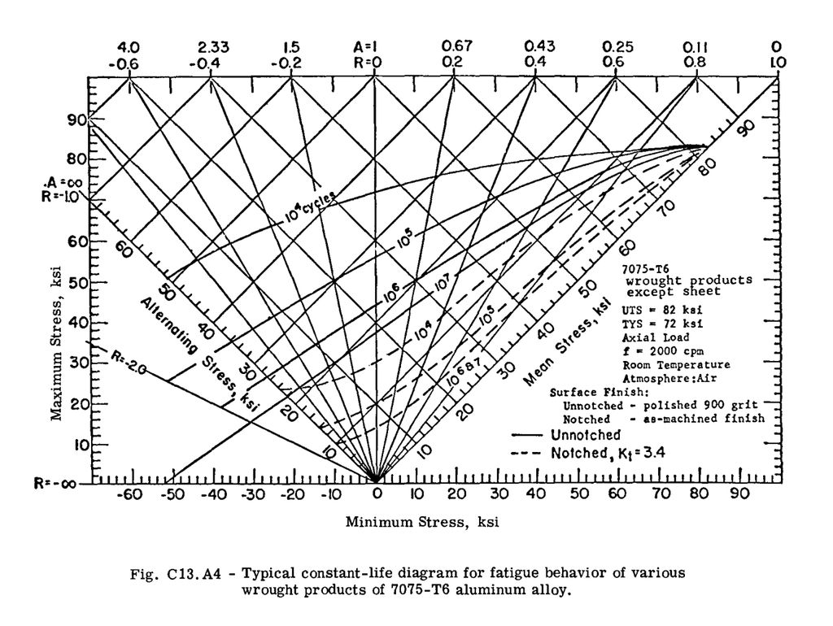

Fig. C13.A4

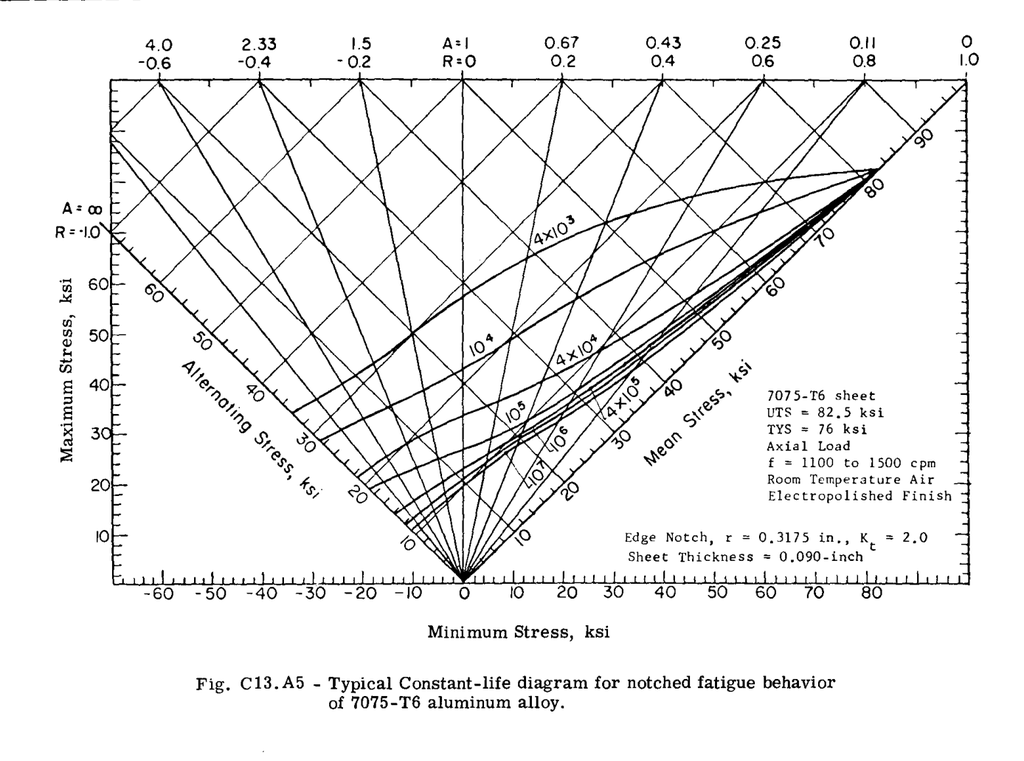

Fig. C13.A5

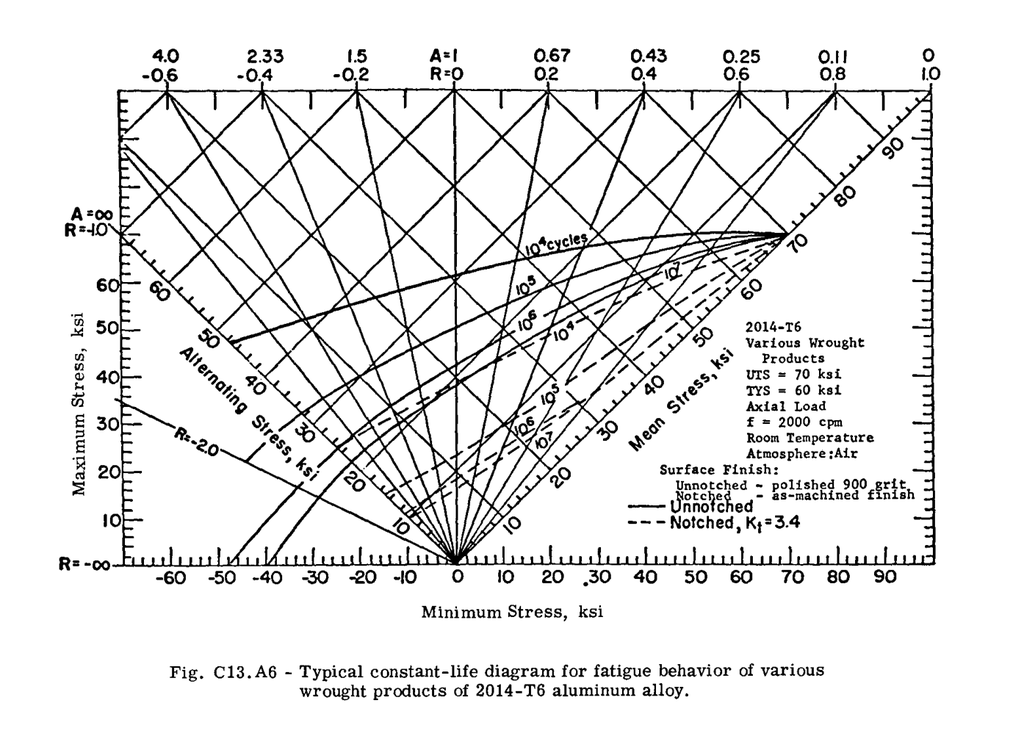

Fig. C13.A6

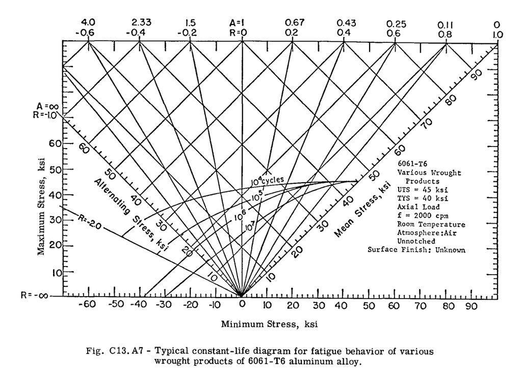

Fig. C13.A7

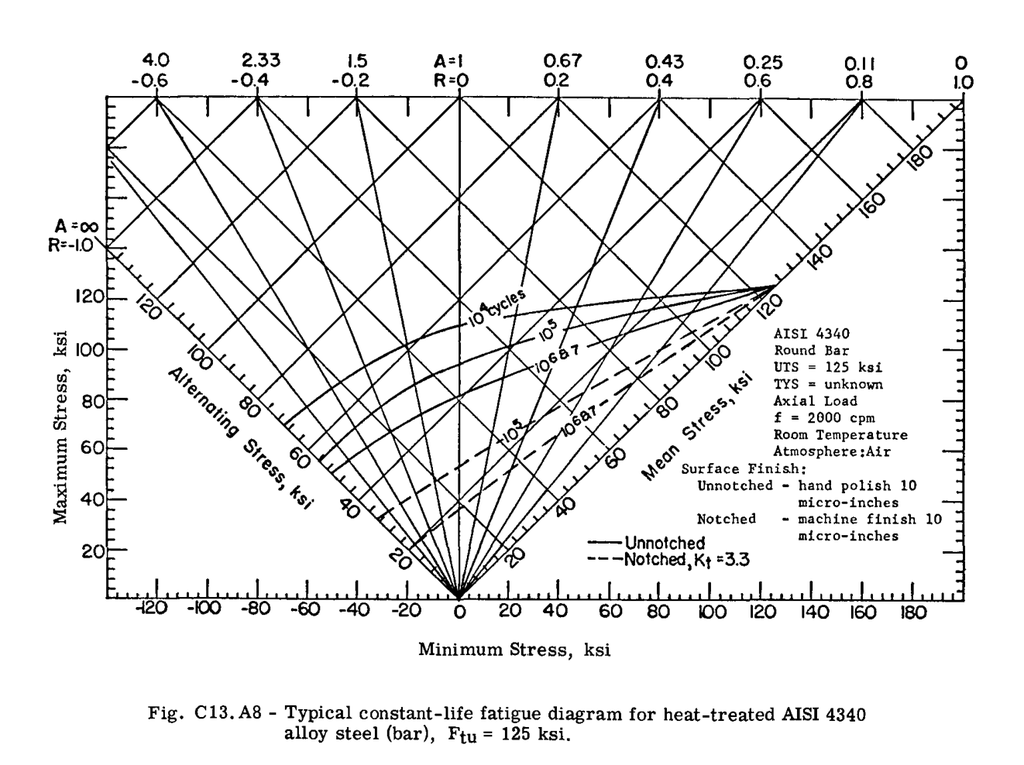

Fig. C13.A8

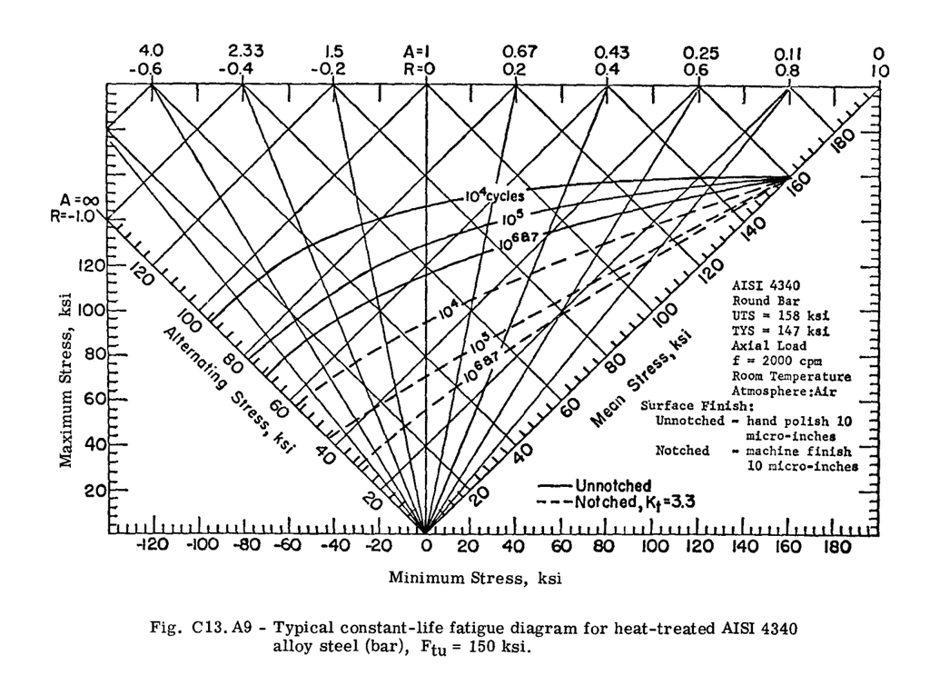

Fig. C13.A9

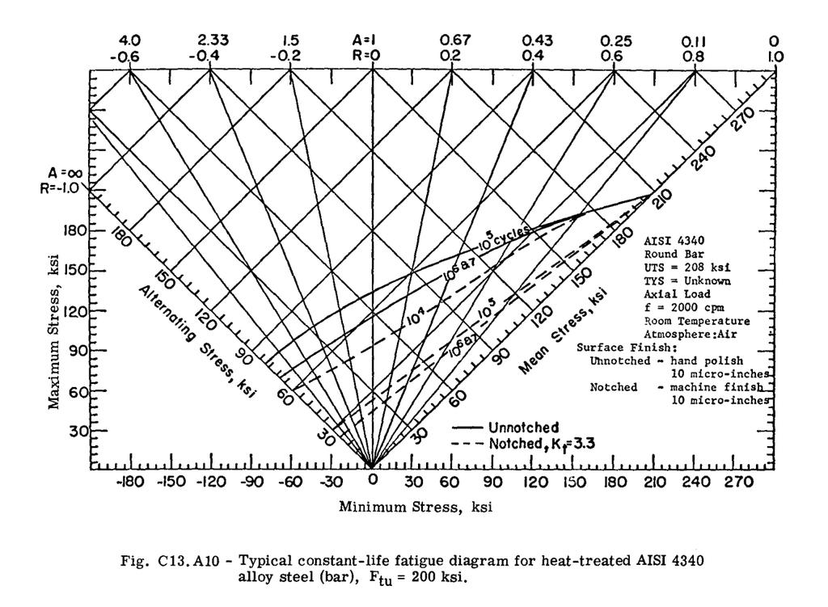

Fig. C13.A10

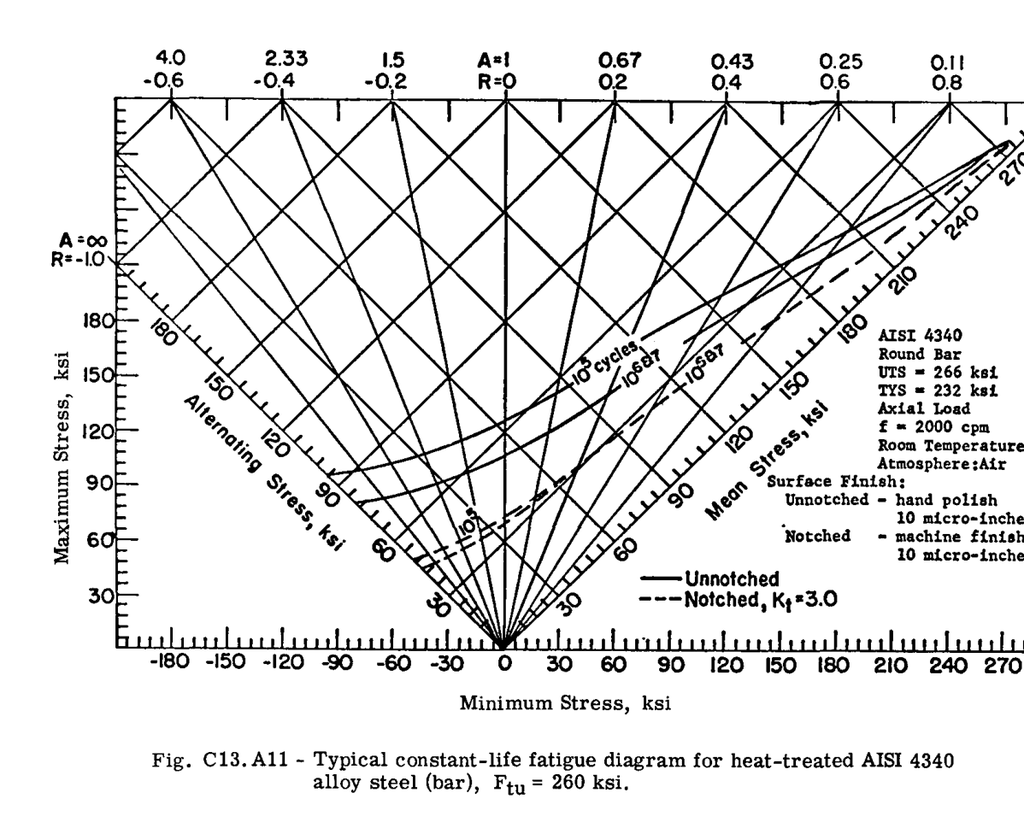

Fig. C13.A11

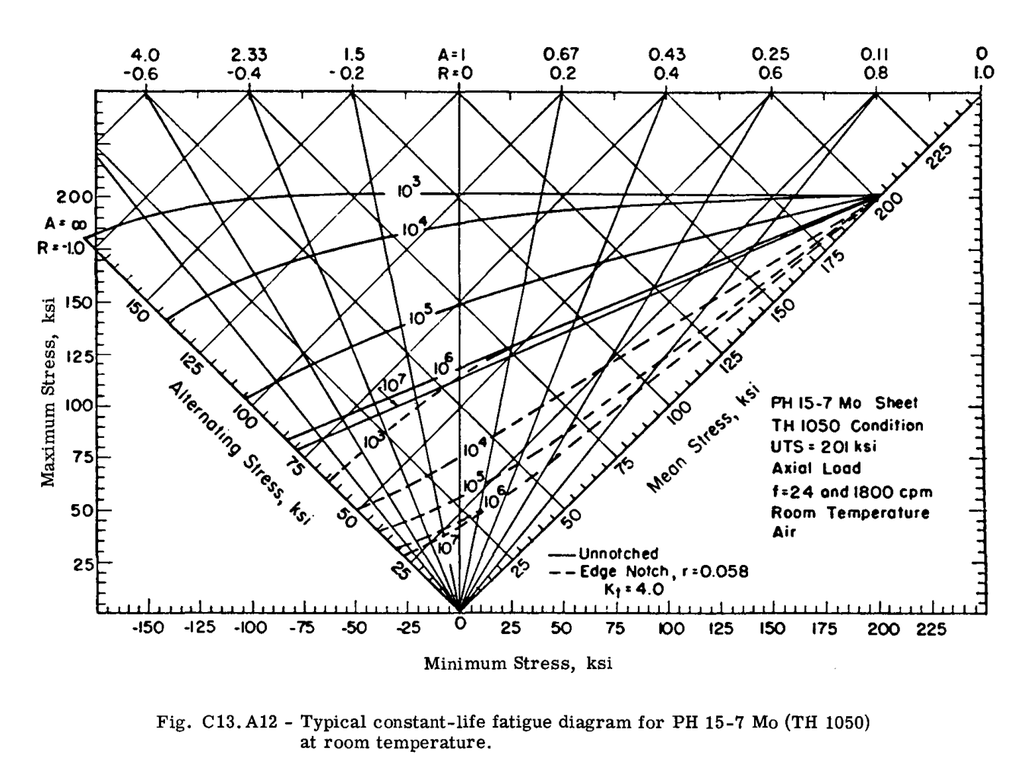

Fig. C13.A12

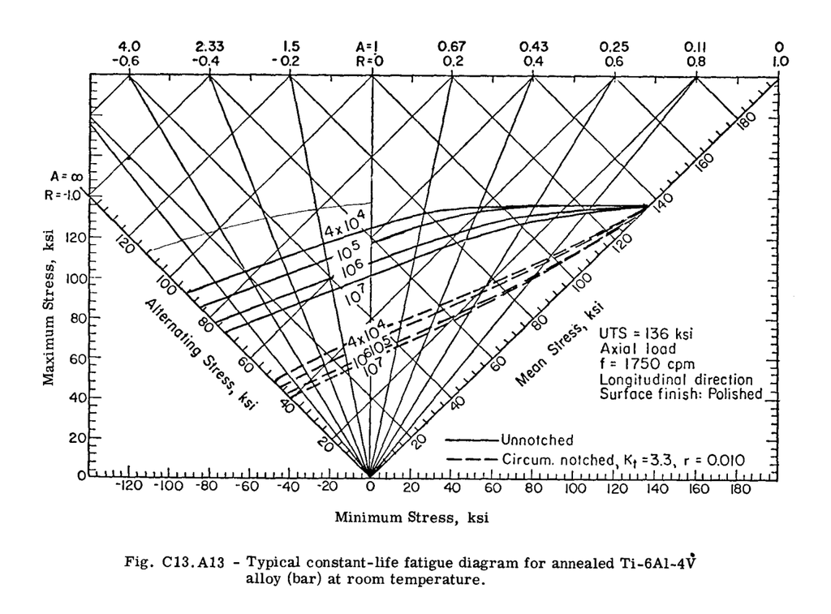

Fig. C13.A13

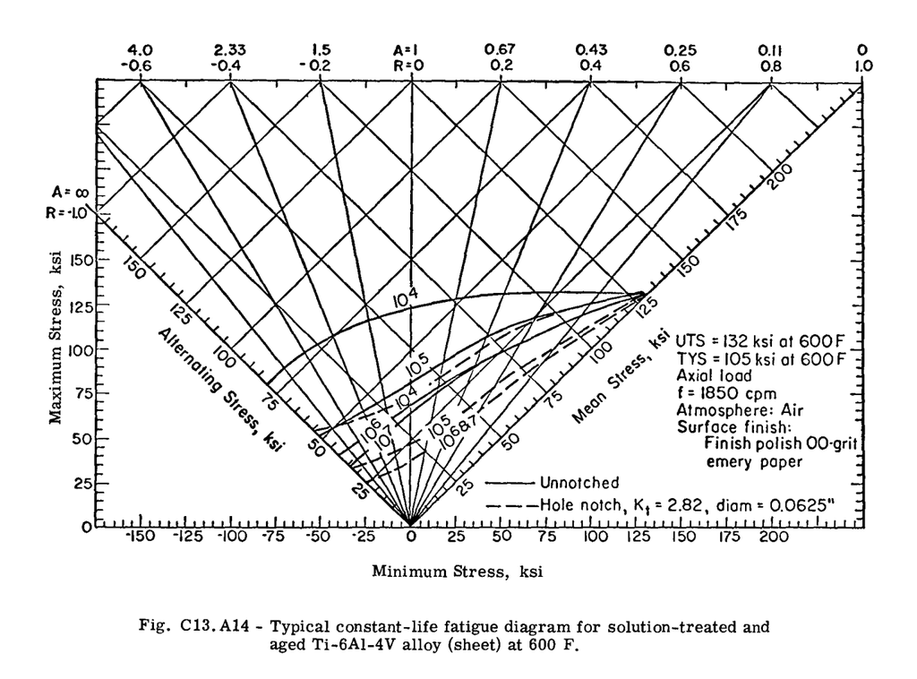

Fig. C13.A14